# Steelhead Adult Rearing Habitat

Sadie Gill, Mark Tompkins

December 18, 2018 (Updated July 2020)

This document develops a method for scaling the available adult steelhead WUA data to the other watersheds.

## Adult Trout and Steelhead WUAs

There is habitat modeling for adult trout or steelhead on 5 watersheds:

**Adult Trout**

1. Battle Creek
2. Butte Creek

**Steelhead**

3. Merced River
4. Tuolumne River
5. Yuba River

## Modeled WUA Exploration

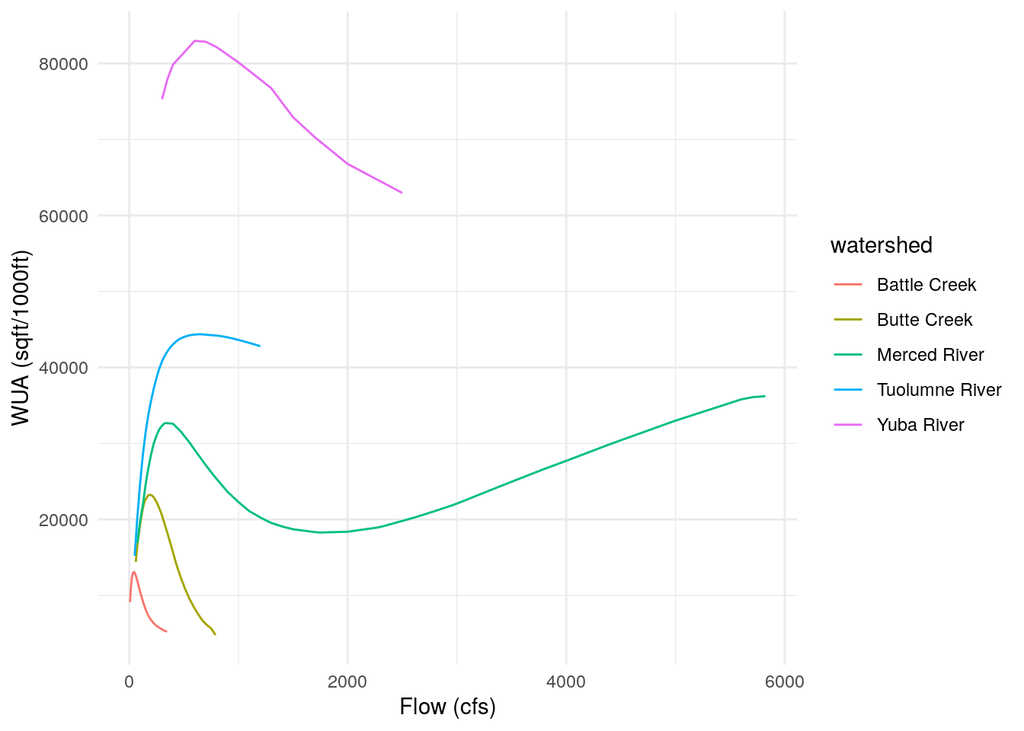

Yuba and Tuolumne WUA values are much higher than the other watersheds, they appear to be proporitonately higher based on watershed size.

Below are the mean values of flow in the monthes December through May. Tuolumne is about twice that of Merced and Yuba is about four times Merced. This is similar to the differences between these watershed’s WUA curves.

| Watershed | Mean Flow (cfs) | Mean Flow Ratio (watershed:Merced) |
| --- | --- | --- |
| Merced River | 1058.413 | 1.00 |
| Tuolumne River | 2058.862 | 1.95 |
| Yuba River | 3889.543 | 3.67 |

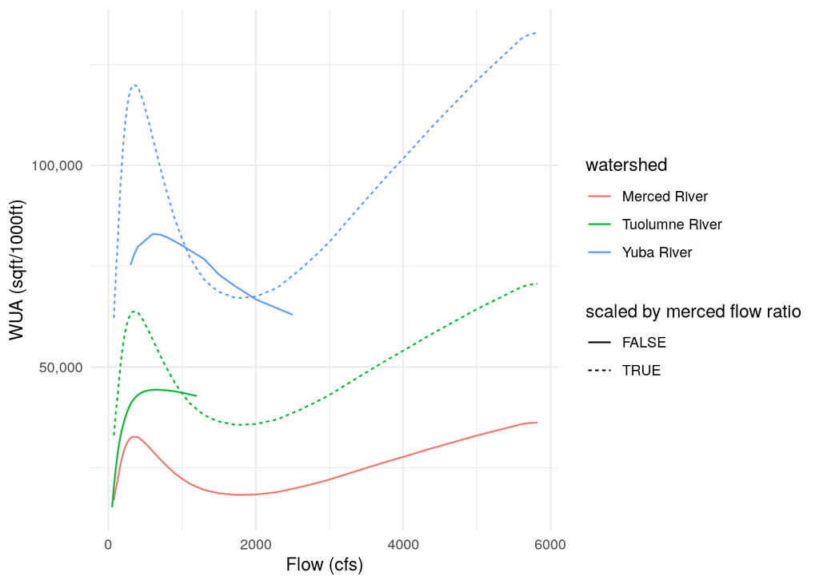

## Method

For unmodeled watersheds, we will take the annual mean flow for the watershed and calculate the wua value using Merced’s modeled relationship. We will then scale the wua by the ratio of mean flow between the watershed and Merced.

Here is a plot of the ratios (the black verticle line is at 1)

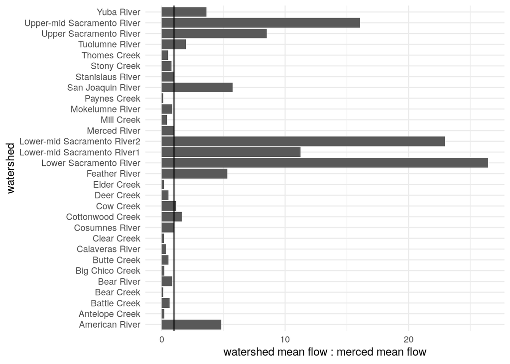

The estimated mean adult rearing habitat for unmodeled watersheds is below

| watershed | square meters |
| --- | --- |
| Upper Sacramento River | 8944321.31 |
| Antelope Creek | 106909.73 |
| Bear Creek | 20504.44 |
| Big Chico Creek | 78743.04 |
| Clear Creek | 49035.94 |
| Cottonwood Creek | 2092731.34 |
| Cow Creek | 1042563.42 |
| Deer Creek | 373867.02 |
| Elder Creek | 19330.35 |
| Mill Creek | 343875.64 |
| Paynes Creek | 32969.12 |
| Stony Creek | 240272.49 |
| Thomes Creek | 324055.26 |
| Upper-mid Sacramento River | 34946272.30 |
| Bear River | 305537.16 |
| Feather River | 6135725.75 |
| American River | 1902786.55 |
| Lower Sacramento River | 6438367.80 |
| Calaveras River | 97816.52 |
| Cosumnes River | 433246.55 |
| Mokelumne River | 560638.25 |
| Stanislaus River | 612775.32 |
| San Joaquin River | 4663176.13 |